# Fallstudie Tips

## Streuungsdiagramme

Auch dies erhalten wir mit Hilfe eines neuen geoms, in diesem Fall *geom_points*. Wir bereiten dabei gleich vor, dass wir auch noch eine Scatterplot-Matrix mit *facet_grid* erstellen werden und speichern eines der Streuungsdiagramme als Variable für die Wiederverwendung ab.

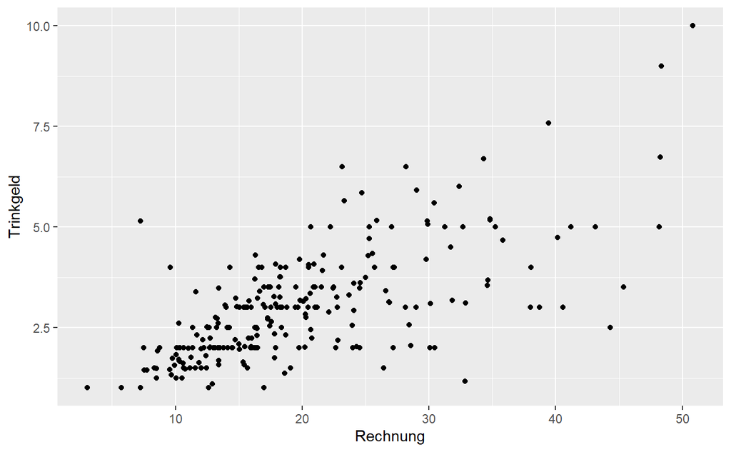

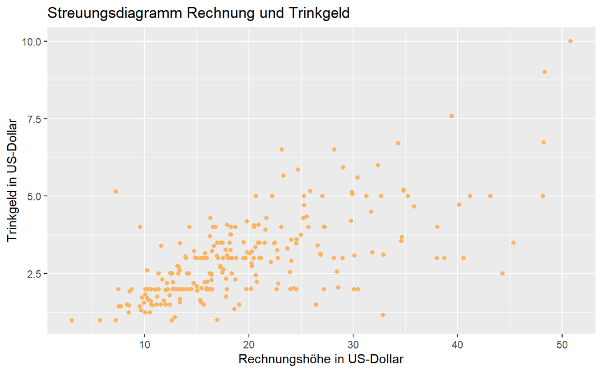

Wir können auch weitere Streuungsdiagramme erstellen, selbst wenn auf einer der Achsen ein diskretes Merkmal wie die Anzahl der Gäste zu finden ist. In diesem Fall ist das geom *geom_jitter* nützlich, das die x-Werte der dargestellten Punkte verrauscht. Dies zeigen wir am Beispiel *Anzahl ~ Trinkgeld*.

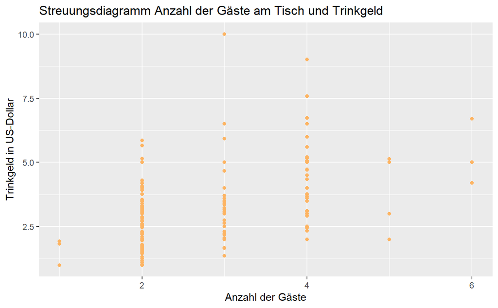

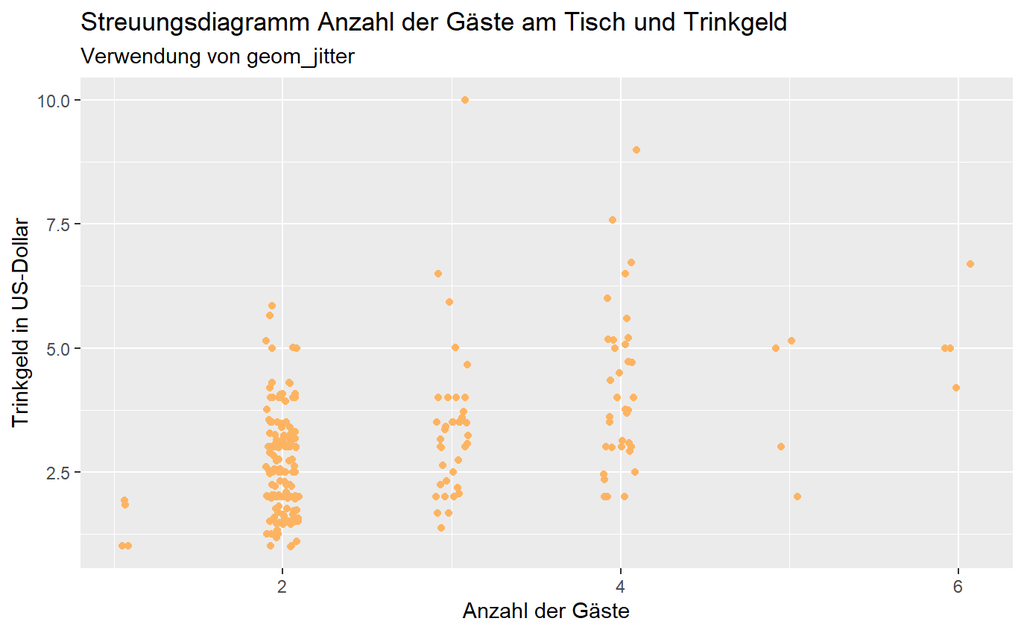

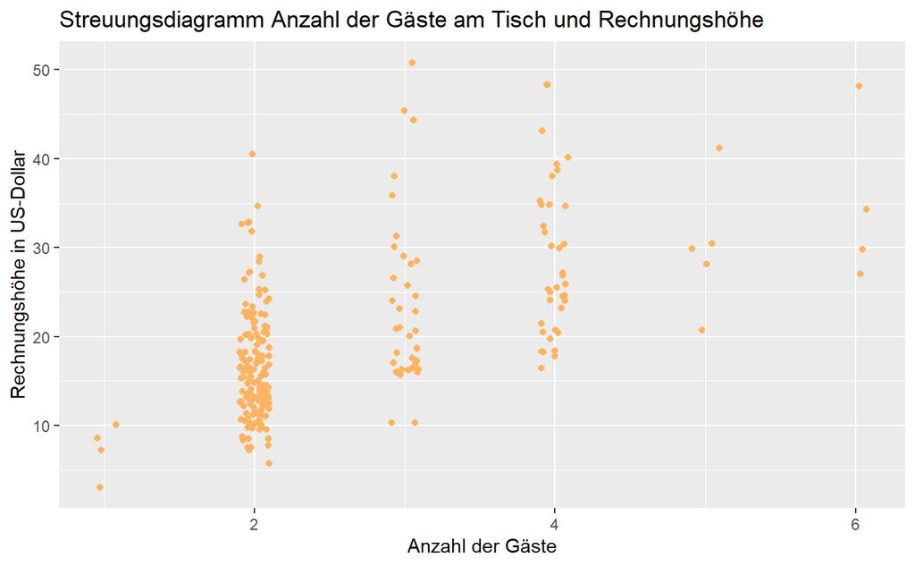

## SPLOM

Wir könnten mit *pairs* eine komplette SPLOM ausgeben, worauf wir aber verzichten. Aber wir verwenden *facet_grid* und erstellen eine kleine Matrix mit Streuungsdiagrammen.

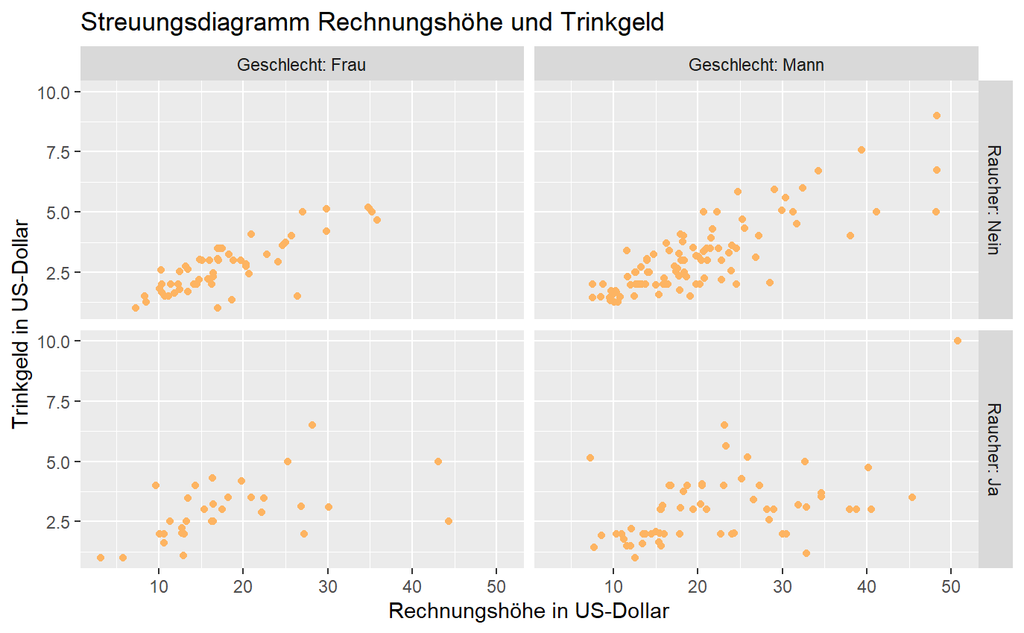

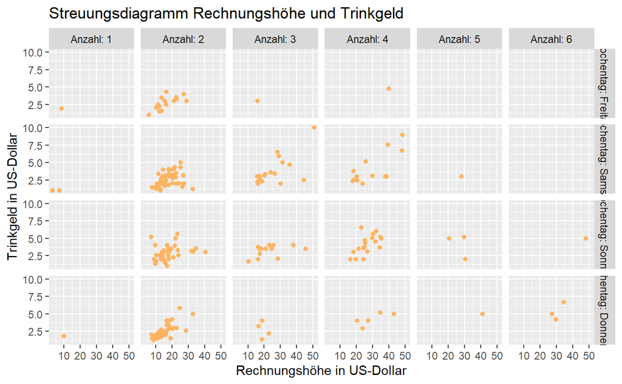

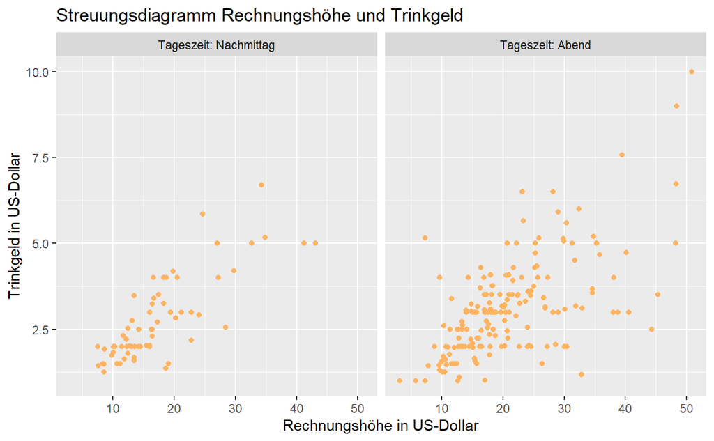

## Heatmaps

Eine weitere Möglichkeit, die vermuteten Zusammenhänge zu visualisieren sind Heatmaps, die wir mit *geom_tile* erstellen können. Die numerischen Merkmale der Rechnungshöhe und des Trinkgelds müssen wir dafür in Klassen einteilen, wie das bereits bei den Histogrammen erfolgt ist. Darauf wird hier verzichtet, wir erstellen exemplarisch eine Heatmap, die den Zusammenhang zwischen Geschlecht der zahlenden Person und dem Wochentag visualisiert. Dazu erzeugen wir ein weiteres *tibble*, das die Häufigkeiten der Kombinationen zwischen diesen beiden Merkmalen bestimmt und damit die Heatmap füllt.

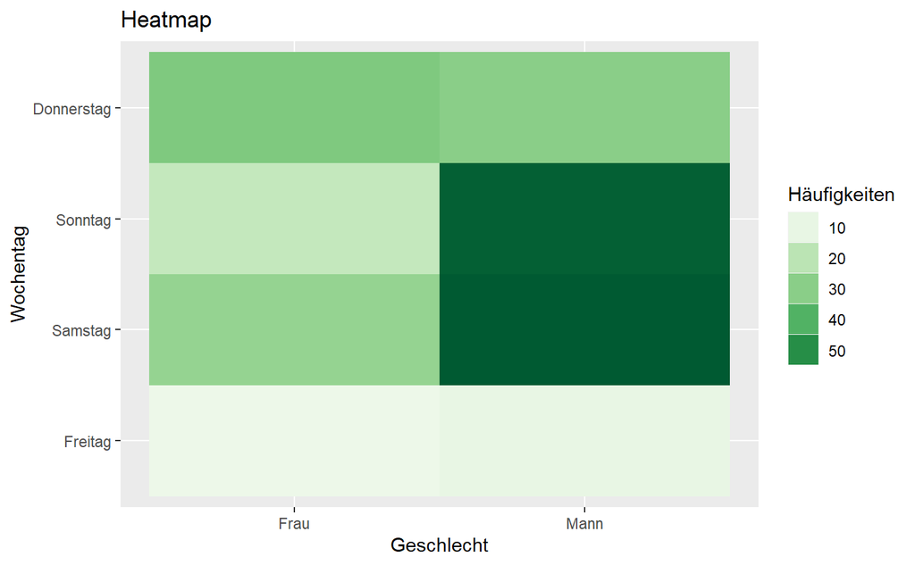

```r
daten %>%
  group_by(Geschlecht, Wochentag) %>%
  mutate(value=n()) %>%
  ggplot() +
    geom_tile(mapping=aes(x=Geschlecht, y=Wochentag, fill=value)) +
    scale_fill_distiller(palette="Greens",
                        guide="legend",
                        direction=1) +
   guides(fill=guide_legend(title="Häufigkeiten")) +
   labs(
    title="Heatmap",
    x="Geschlecht",
    y="Wochentag"
   )

ggsave(filename="tipsHeat1.png", plot=last_plot(),
       device="png",
       path="images/",
       width=16,
       height=9,
       units="cm")
```

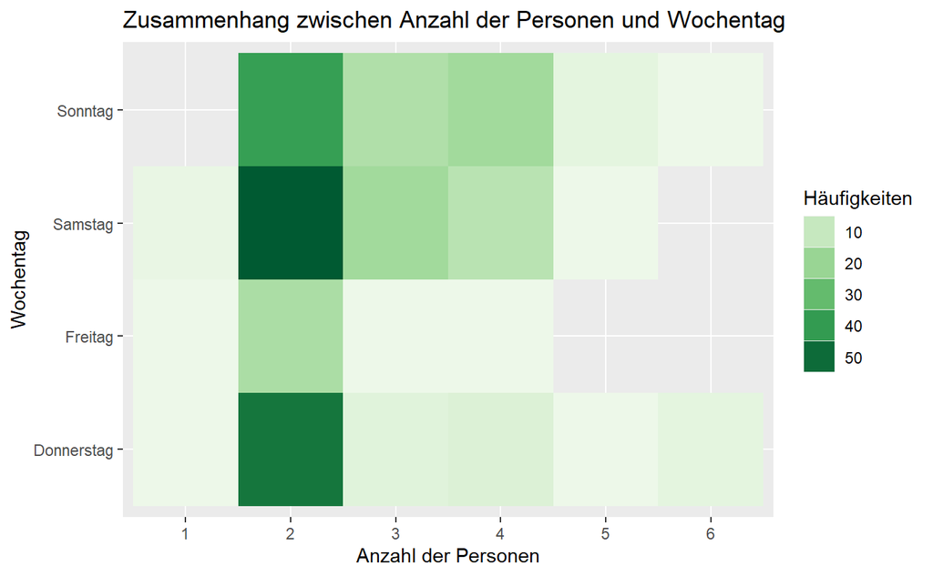

```r
daten %>%
  group_by(factor(Anzahl), Wochentag) %>%
  mutate(value=n()) %>%
  ggplot() +
    geom_tile(mapping=aes(x=factor(Anzahl), y=Wochentag, fill=value)) +
    scale_y_discrete(limits=c("Donnerstag", "Freitag", "Samstag", "Sonntag"),
                     breaks=c("Donnerstag", "Freitag", "Samstag", "Sonntag")) +
    scale_fill_distiller(palette="Greens",
                        guide="legend",
                        direction=1) +
   guides(fill=guide_legend(title="Häufigkeiten")) +
   labs(
    title="Zusammenhang zwischen Anzahl der Personen und Wochentag",
    x="Anzahl der Personen",
    y="Wochentag"
   )
```

# Erweiterungen

Dass die Höhe des Trinkgelds von der Rechnungshöhe abhängt ist offensichtlich und auch zu erwarten gewesen. Deshalb findet man in der Literatur den Vorschlag, das Verhältnis zwischen Höhe des Trinkgelds und der Rechnungshöhe als weitere Einflussvariable zu erstellen und dem Datensatz hinzuzufügen. Wir nennen diese Variable *Trinkgeldrate*. Wir fügen diese Variable mit Hilfe von *mutate* zu unserem Datensatz hinzu.

```r
daten <- daten %>%
  mutate(
    Trinkgeldrate=Trinkgeld/Rechnung) %>%
  select(Rechnung, Trinkgeld, Trinkgeldrate, everything())

kable(head(daten), align="l",
      caption="Tabelle 9: Der Datensatz mit einem weiteren Merkmal") %>%
      kable_styling(bootstrap_options = c("striped", "condensed"),
                full_width = T,
                position = "center")
```

Tabelle 9: Der Datensatz mit einem weiteren Merkmal

| Rechnung | Trinkgeld | Trinkgeldrate | Geschlecht | Raucher | Wochentag | Tageszeit | Anzahl |
| --- | --- | --- | --- | --- | --- | --- | --- |
| 17.0 | 1.01 | 0.059 | Frau | Nein | Sonntag | Abend | 2 |
| 10.3 | 1.66 | 0.161 | Mann | Nein | Sonntag | Abend | 3 |
| 21.0 | 3.50 | 0.167 | Mann | Nein | Sonntag | Abend | 3 |
| 23.7 | 3.31 | 0.140 | Mann | Nein | Sonntag | Abend | 2 |
| 24.6 | 3.61 | 0.147 | Frau | Nein | Sonntag | Abend | 4 |
| 25.3 | 4.71 | 0.186 | Mann | Nein | Sonntag | Abend | 4 |

Wir visualisieren die neu eingeführte Variable, um uns zu überzeugen, dass wir damit eine gut einsetzbare Variable erzeugt haben.

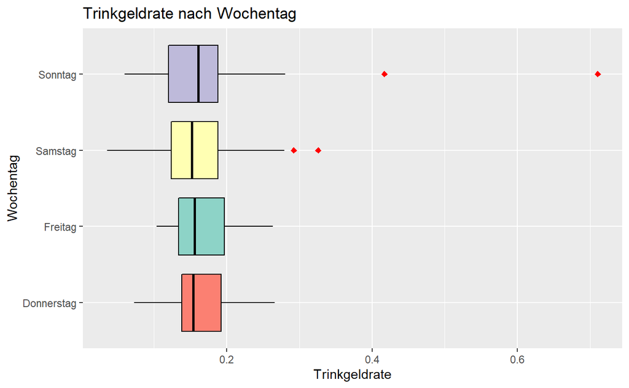

```r
ggplot(daten,
       aes(x=Wochentag, y=Trinkgeldrate, fill=Wochentag)) +
  geom_boxplot(color="black",
               outlier.color="red",
               outlier.fill="red",
               outlier.shape=23,
               outlier.size=1.5,
               show.legend=FALSE) +
  scale_fill_brewer(palette="Set3") +
  scale_x_discrete(limits=c("Donnerstag", "Freitag", "Samstag", "Sonntag"),
                   breaks=c("Donnerstag", "Freitag", "Samstag", "Sonntag")) +
  labs(
         title="Trinkgeldrate nach Wochentag",
         x="Wochentag",
         y="Trinkgeldrate"
  ) +
  coord_flip()
```

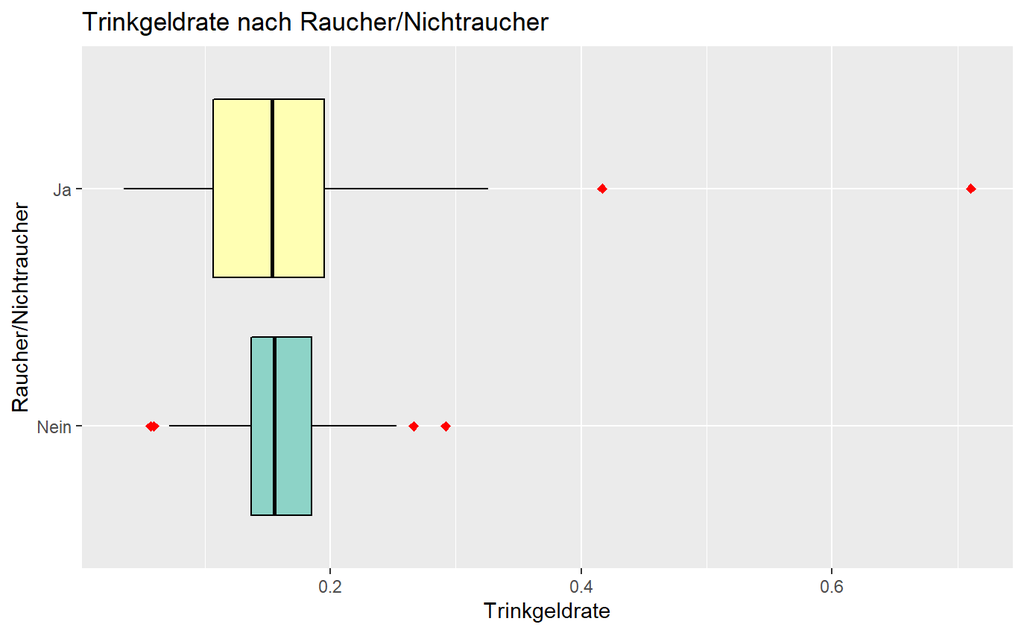

```r
ggplot(daten,
       aes(x=Raucher, y=Trinkgeldrate, fill=Raucher)) +
  geom_boxplot(color="black",
               outlier.color="red",
               outlier.fill="red",
               outlier.shape=23,
               outlier.size=1.5,
               show.legend=FALSE) +
  scale_fill_brewer(palette="Set3") +
  labs(
         title="Trinkgeldrate nach Raucher/Nichtraucher",
         x="Raucher/Nichtraucher",
         y="Trinkgeldrate"
  ) +
  coord_flip()
```

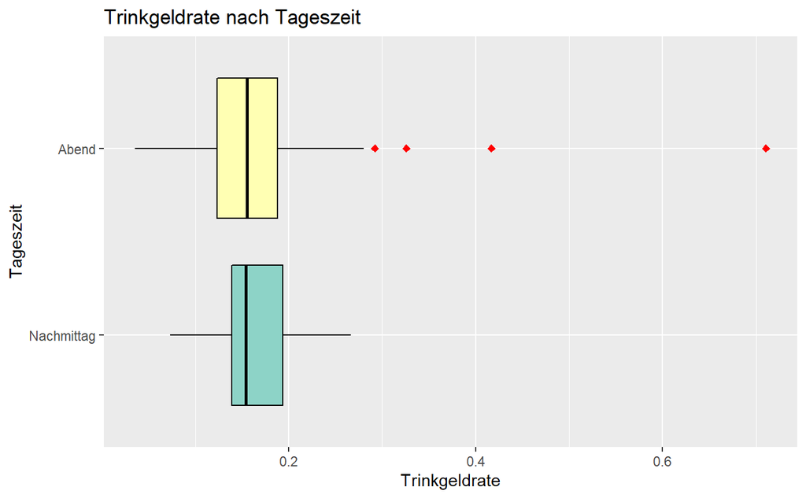

```r
ggplot(daten,
       aes(x=Tageszeit, y=Trinkgeldrate, fill=Tageszeit)) +
  geom_boxplot(color="black",
               outlier.color="red",
               outlier.fill="red",
               outlier.shape=23,
               outlier.size=1.5,
               show.legend=FALSE) +
  scale_fill_brewer(palette="Set3") +
  labs(
         title="Trinkgeldrate nach Tageszeit",
         x="Tageszeit",
         y="Trinkgeldrate"
  ) +
  coord_flip()

ggsave(filename="tipsRateZeit.png", plot=last_plot(),
       device="png",
       path="images/",
       width=16,
       height=9,
       units="cm")
```

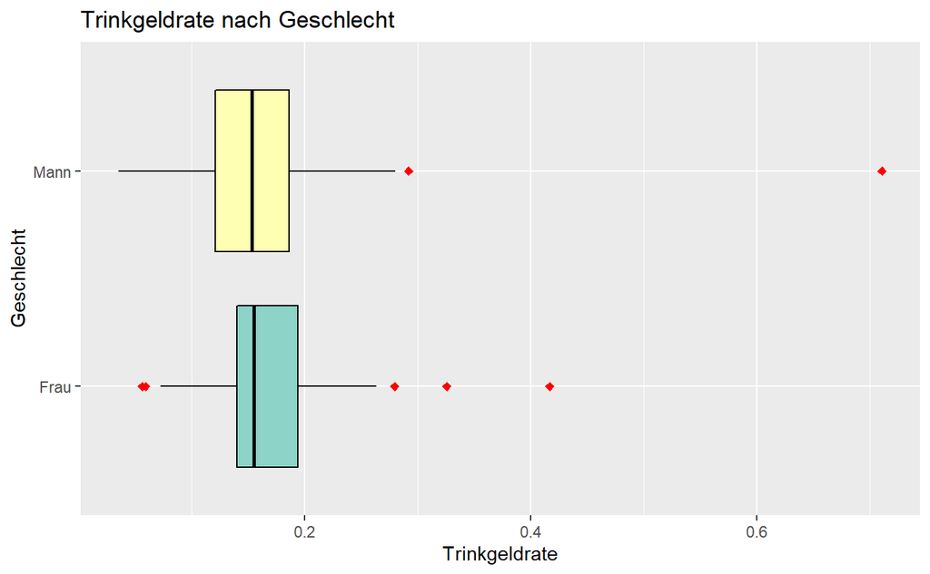

```r
ggplot(daten,
       aes(x=Geschlecht, y=Trinkgeldrate, fill=Geschlecht)) +
  geom_boxplot(color="black",
               outlier.color="red",
               outlier.fill="red",
               outlier.shape=23,
               outlier.size=1.5,
               show.legend=FALSE) +
  scale_fill_brewer(palette="Set3") +
  labs(
         title="Trinkgeldrate nach Geschlecht",
         x="Geschlecht",
         y="Trinkgeldrate"
  ) +
  coord_flip()
```

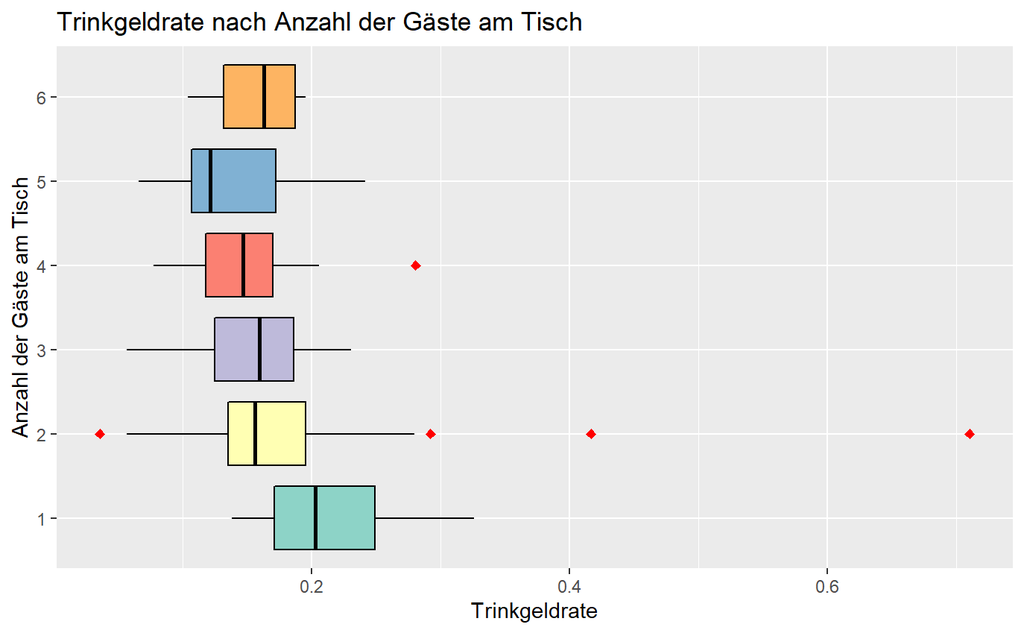

```r
ggplot(daten,
       aes(x=factor(Anzahl),
           y=Trinkgeldrate,
           fill=factor(Anzahl))) +
  geom_boxplot(color="black",
               outlier.color="red",
               outlier.fill="red",
               outlier.shape=23,
               outlier.size=1.5,
               show.legend=FALSE) +
  scale_fill_brewer(palette="Set3") +
  labs(
         title="Trinkgeldrate nach Anzahl der Gäste am Tisch",
         x="Anzahl der Gäste am Tisch",
         y="Trinkgeldrate"
  ) +
  coord_flip()

ggsave(filename="tipsRateAnzahl.png", plot=last_plot(),
       device="png",
       path="images/",
       width=16,
       height=9,
       units="cm")
```

# Abspeichern der Daten

Wir werden auf der Basis des veränderten Datensatzes Modelle und Vorhersagen erstellen. Dazu speichern wir die neuen Daten in der Datei *tipsWithRate.csv” im Unterverzeichnis* data* ab. Spaltentrenner ist das Semikolon, als Dezimaltrenner wird das Komma verwendet, so dass wir diese neue Datei mit Hilfe von *read_csv2* einlesen können.

# Literatur

Bryant, and Smith. 2003. *Practical Data Analysis: Case Studies in Business Statistics*. Irwin Professional Pub.

Martin Theus, Simon Urbanek. 2009. *Interactive Graphics for Data Analysis*. CRC Press.

Swayne, Dianne Cook Deborah. 2007. *Interactive and Dynamic Graphics for Data Analysis*. Springer.